# SG_01_FUNDRAISER_ADDR_CITY

Fundraiser city · Text report

## Overview

**Description**

Foreign Address - City

**Table**

`SG-P01-T01-FUNDRAISERS-INFO` (many)

**Location code**

`SCHED-G-PART-01-LINE-02B-COL-i`

**Family**

`SCHED-G-PART-01-LINE-02B-COL-i` · siblings: SG_01_FUNDRAISER_ADDR_CNTR, SG_01_FUNDRAISER_ADDR_L1, SG_01_FUNDRAISER_ADDR_L2, SG_01_FUNDRAISER_ADDR_STATE, SG_01_FUNDRAISER_ADDR_ZIP, SG_01_FUNDRAISER_NAME_INDIV

**Data type**

text (xsd: )

**Scope**

PZ

**Status**

unreviewed

6

xpaths mapped (6 observed)

68,746

filings with a value

2010–2024

tax years observed

4

open flags (1 errors)

## Flags

| Severity | Flag | Xpath | Detail |
| --- | --- | --- | --- |
| ⚠ error | `COLLISION` | IRS990ScheduleG/FundraiserActivityInfoGrp/ForeignAddress/CityNm | 539 filings contain 2+ of its xpaths; most common set: /Return/ReturnData/IRS990ScheduleG/FundraiserActivityInfoGrp/ForeignAddress/CityNm ; /Return/ReturnData/IRS990ScheduleG/FundraiserActivityInfoGrp… |
| ⓘ info | `MANY_NOT_REPEATING` | IRS990ScheduleG/FundraiserActivityInfoGrp/USAddress/CityNm | many-to-one table, but 72% of values sit in no repeating element |
| ⓘ info | `MANY_NOT_REPEATING` | IRS990ScheduleG/FundraiserActivityInformation/AddressUS/City | many-to-one table, but 71% of values sit in no repeating element |
| ⓘ info | `MANY_NOT_REPEATING` | IRS990ScheduleG/FundraiserActivityInfoGrp/USAddress/City | many-to-one table, but 71% of values sit in no repeating element |

## Xpaths

All mapped xpaths (under /Return/ReturnData or /Return/ReturnHeader), oldest first. Charts label each series by its xpath.

| Xpath | Form | Chart label | First year | Last year | Versions | Filings | Repeats in |
| --- | --- | --- | --- | --- | --- | --- | --- |
| IRS990ScheduleG/FundraiserActivityInformation/AddressUS/City | Sched G | same | 2010 | 2012 | 12 | 9,547 | 28.5% |
| IRS990ScheduleG/FundraiserActivityInformation/AddressForeign/City | Sched G | …heduleG/FundraiserActivityInformation/AddressForeign/City | 2010 | 2012 | 9 | 91 | 14.3% |
| IRS990ScheduleG/FundraiserActivityInfoGrp/USAddress/City | Sched G | same | 2013 | 2013 | 3 | 4,040 | 27.6% |
| IRS990ScheduleG/FundraiserActivityInfoGrp/ForeignAddress/City | Sched G | …90ScheduleG/FundraiserActivityInfoGrp/ForeignAddress/City | 2013 | 2013 | 3 | 38 | 10.5% |
| IRS990ScheduleG/FundraiserActivityInfoGrp/USAddress/CityNm | Sched G | same | 2014 | 2024 | 34 | 54,332 | 27.1% |
| IRS990ScheduleG/FundraiserActivityInfoGrp/ForeignAddress/CityNm | Sched G | …ScheduleG/FundraiserActivityInfoGrp/ForeignAddress/CityNm | 2014 | 2024 | 32 | 698 | 18.3% |

## Coverage

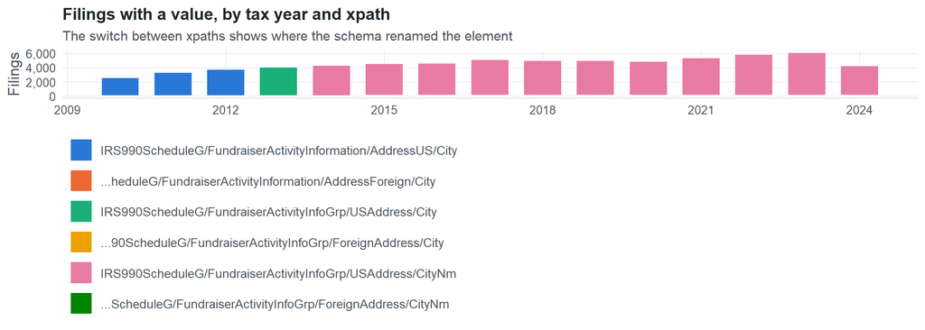

**Table view**

Table view: filings by tax year and series

| Tax year | IRS990ScheduleG/FundraiserActivityInformation/AddressUS/City | …heduleG/FundraiserActivityInformation/AddressForeign/City | IRS990ScheduleG/FundraiserActivityInfoGrp/USAddress/City | …90ScheduleG/FundraiserActivityInfoGrp/ForeignAddress/City | IRS990ScheduleG/FundraiserActivityInfoGrp/USAddress/CityNm | …ScheduleG/FundraiserActivityInfoGrp/ForeignAddress/CityNm |
| --- | --- | --- | --- | --- | --- | --- |
| 2010 | 2,546 | 26 | 0 | 0 | 0 | 0 |
| 2011 | 3,261 | 31 | 0 | 0 | 0 | 0 |
| 2012 | 3,740 | 34 | 0 | 0 | 0 | 0 |
| 2013 | 0 | 0 | 4,040 | 38 | 0 | 0 |
| 2014 | 0 | 0 | 0 | 0 | 4,268 | 42 |
| 2015 | 0 | 0 | 0 | 0 | 4,502 | 50 |
| 2016 | 0 | 0 | 0 | 0 | 4,586 | 51 |
| 2017 | 0 | 0 | 0 | 0 | 5,043 | 51 |
| 2018 | 0 | 0 | 0 | 0 | 4,932 | 54 |
| 2019 | 0 | 0 | 0 | 0 | 4,909 | 54 |
| 2020 | 0 | 0 | 0 | 0 | 4,794 | 63 |
| 2021 | 0 | 0 | 0 | 0 | 5,278 | 79 |
| 2022 | 0 | 0 | 0 | 0 | 5,772 | 109 |
| 2023 | 0 | 0 | 0 | 0 | 6,040 | 88 |
| 2024 | 0 | 0 | 0 | 0 | 4,208 | 57 |

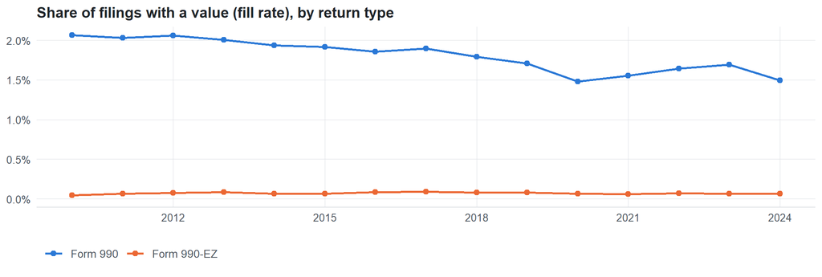

**Table view**

Table view: fill rate

| Tax year | Return type | Filings | All filings | Fill rate |
| --- | --- | --- | --- | --- |
| 2010 | Form 990 | 2,542 | 123,025 | 2.07% |
| 2010 | Form 990-EZ | 30 | 63,326 | 0.05% |
| 2011 | Form 990 | 3,237 | 159,504 | 2.03% |
| 2011 | Form 990-EZ | 55 | 82,048 | 0.07% |
| 2012 | Form 990 | 3,703 | 179,688 | 2.06% |
| 2012 | Form 990-EZ | 71 | 93,750 | 0.08% |
| 2013 | Form 990 | 3,989 | 198,855 | 2.01% |
| 2013 | Form 990-EZ | 89 | 104,375 | 0.09% |
| 2014 | Form 990 | 4,233 | 218,619 | 1.94% |
| 2014 | Form 990-EZ | 77 | 116,417 | 0.07% |
| 2015 | Form 990 | 4,471 | 233,519 | 1.91% |
| 2015 | Form 990-EZ | 81 | 124,894 | 0.06% |
| 2016 | Form 990 | 4,524 | 243,903 | 1.85% |
| 2016 | Form 990-EZ | 113 | 130,484 | 0.09% |
| 2017 | Form 990 | 4,966 | 261,612 | 1.90% |
| 2017 | Form 990-EZ | 128 | 139,144 | 0.09% |
| 2018 | Form 990 | 4,864 | 271,442 | 1.79% |
| 2018 | Form 990-EZ | 122 | 149,384 | 0.08% |
| 2019 | Form 990 | 4,844 | 283,694 | 1.71% |
| 2019 | Form 990-EZ | 119 | 152,622 | 0.08% |
| 2020 | Form 990 | 4,746 | 320,342 | 1.48% |
| 2020 | Form 990-EZ | 111 | 169,864 | 0.07% |
| 2021 | Form 990 | 5,232 | 336,480 | 1.55% |
| 2021 | Form 990-EZ | 125 | 202,724 | 0.06% |
| 2022 | Form 990 | 5,732 | 349,055 | 1.64% |
| 2022 | Form 990-EZ | 149 | 206,130 | 0.07% |
| 2023 | Form 990 | 5,998 | 354,768 | 1.69% |
| 2023 | Form 990-EZ | 130 | 206,379 | 0.06% |
| 2024 | Form 990 | 4,149 | 277,298 | 1.50% |
| 2024 | Form 990-EZ | 116 | 178,867 | 0.06% |

## Repeating groups

Table cardinality in the concordance: **many**. 6 of 6 observed xpaths repeat within a filing.

Repeating element each xpath was observed in (from the raw indexed xpath)

| Xpath | Repeating element | Filings (summed over years) |
| --- | --- | --- |
| IRS990ScheduleG/FundraiserActivityInformation/AddressForeign/City | (none) | 29 |
| IRS990ScheduleG/FundraiserActivityInformation/AddressForeign/City | IRS990ScheduleG/FundraiserActivityInformation | 62 |
| IRS990ScheduleG/FundraiserActivityInformation/AddressUS/City | (none) | 6758 |
| IRS990ScheduleG/FundraiserActivityInformation/AddressUS/City | IRS990ScheduleG/FundraiserActivityInformation | 2789 |
| IRS990ScheduleG/FundraiserActivityInfoGrp/ForeignAddress/City | (none) | 16 |
| IRS990ScheduleG/FundraiserActivityInfoGrp/ForeignAddress/City | IRS990ScheduleG/FundraiserActivityInfoGrp | 22 |
| IRS990ScheduleG/FundraiserActivityInfoGrp/USAddress/City | (none) | 2886 |
| IRS990ScheduleG/FundraiserActivityInfoGrp/USAddress/City | IRS990ScheduleG/FundraiserActivityInfoGrp | 1154 |
| IRS990ScheduleG/FundraiserActivityInfoGrp/ForeignAddress/CityNm | (none) | 200 |
| IRS990ScheduleG/FundraiserActivityInfoGrp/ForeignAddress/CityNm | IRS990ScheduleG/FundraiserActivityInfoGrp | 498 |
| IRS990ScheduleG/FundraiserActivityInfoGrp/USAddress/CityNm | (none) | 39016 |
| IRS990ScheduleG/FundraiserActivityInfoGrp/USAddress/CityNm | IRS990ScheduleG/FundraiserActivityInfoGrp | 15316 |

## Values

| Result | Check | Detail |
| --- | --- | --- |
| ✓ pass | Values are text, not numbers | 0% of values are numeric |
| ✓ pass | No sign of truncation | longest values do not sit at a common field limit |
| ⓘ info | No dominant boilerplate value | most common value covers 27% of filings: “TORONTO” |

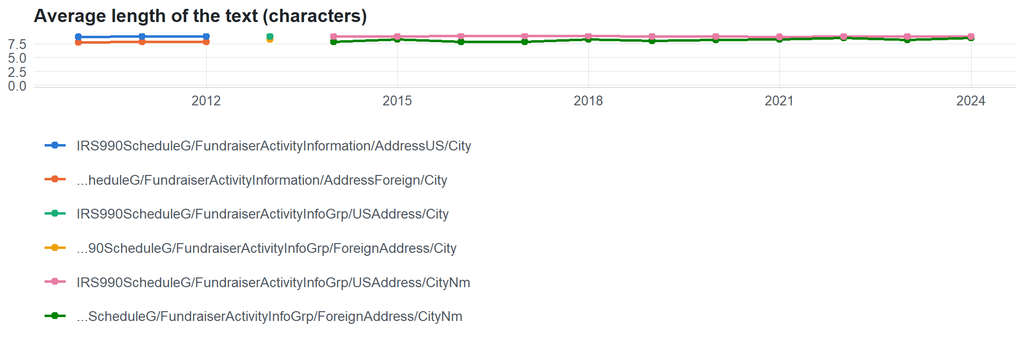

**Table view**

Table view: length and variety by tax year

| Series | Tax year | Filings | Avg length | Max length | Distinct values (approx.) |
| --- | --- | --- | --- | --- | --- |
| IRS990ScheduleG/FundraiserActivityInformation/AddressUS/City | 2010 | 2,546 | 9 | 20 | 755 |
| IRS990ScheduleG/FundraiserActivityInformation/AddressUS/City | 2011 | 3,261 | 9 | 20 | 818 |
| IRS990ScheduleG/FundraiserActivityInformation/AddressUS/City | 2012 | 3,740 | 9 | 21 | 957 |
| …heduleG/FundraiserActivityInformation/AddressForeign/City | 2010 | 26 | 8 | 16 | 13 |
| …heduleG/FundraiserActivityInformation/AddressForeign/City | 2011 | 31 | 8 | 16 | 13 |
| …heduleG/FundraiserActivityInformation/AddressForeign/City | 2012 | 34 | 8 | 17 | 15 |
| IRS990ScheduleG/FundraiserActivityInfoGrp/USAddress/City | 2013 | 4,040 | 9 | 22 | 954 |
| …90ScheduleG/FundraiserActivityInfoGrp/ForeignAddress/City | 2013 | 38 | 8 | 18 | 12 |
| IRS990ScheduleG/FundraiserActivityInfoGrp/USAddress/CityNm | 2014 | 4,268 | 9 | 22 | 1,217 |
| IRS990ScheduleG/FundraiserActivityInfoGrp/USAddress/CityNm | 2015 | 4,502 | 9 | 20 | 1,289 |
| IRS990ScheduleG/FundraiserActivityInfoGrp/USAddress/CityNm | 2016 | 4,586 | 9 | 22 | 2,165 |
| IRS990ScheduleG/FundraiserActivityInfoGrp/USAddress/CityNm | 2017 | 5,043 | 9 | 22 | 1,559 |
| IRS990ScheduleG/FundraiserActivityInfoGrp/USAddress/CityNm | 2018 | 4,932 | 9 | 22 | 1,556 |
| IRS990ScheduleG/FundraiserActivityInfoGrp/USAddress/CityNm | 2019 | 4,909 | 9 | 22 | 997 |
| IRS990ScheduleG/FundraiserActivityInfoGrp/USAddress/CityNm | 2020 | 4,794 | 9 | 20 | 1,026 |
| IRS990ScheduleG/FundraiserActivityInfoGrp/USAddress/CityNm | 2021 | 5,278 | 9 | 20 | 1,576 |
| IRS990ScheduleG/FundraiserActivityInfoGrp/USAddress/CityNm | 2022 | 5,772 | 9 | 20 | 1,800 |
| IRS990ScheduleG/FundraiserActivityInfoGrp/USAddress/CityNm | 2023 | 6,040 | 9 | 22 | 1,170 |
| IRS990ScheduleG/FundraiserActivityInfoGrp/USAddress/CityNm | 2024 | 4,208 | 9 | 22 | 946 |
| …ScheduleG/FundraiserActivityInfoGrp/ForeignAddress/CityNm | 2014 | 42 | 8 | 17 | 21 |
| …ScheduleG/FundraiserActivityInfoGrp/ForeignAddress/CityNm | 2015 | 50 | 8 | 17 | 24 |
| …ScheduleG/FundraiserActivityInfoGrp/ForeignAddress/CityNm | 2016 | 51 | 8 | 16 | 35 |
| …ScheduleG/FundraiserActivityInfoGrp/ForeignAddress/CityNm | 2017 | 51 | 8 | 21 | 37 |
| …ScheduleG/FundraiserActivityInfoGrp/ForeignAddress/CityNm | 2018 | 54 | 8 | 18 | 32 |
| …ScheduleG/FundraiserActivityInfoGrp/ForeignAddress/CityNm | 2019 | 54 | 8 | 17 | 21 |
| …ScheduleG/FundraiserActivityInfoGrp/ForeignAddress/CityNm | 2020 | 63 | 8 | 17 | 26 |
| …ScheduleG/FundraiserActivityInfoGrp/ForeignAddress/CityNm | 2021 | 79 | 8 | 17 | 43 |
| …ScheduleG/FundraiserActivityInfoGrp/ForeignAddress/CityNm | 2022 | 109 | 9 | 19 | 99 |
| …ScheduleG/FundraiserActivityInfoGrp/ForeignAddress/CityNm | 2023 | 88 | 8 | 18 | 38 |
| …ScheduleG/FundraiserActivityInfoGrp/ForeignAddress/CityNm | 2024 | 57 | 9 | 19 | 37 |

Most common values by xpath (all years; long values truncated)

| Series | Value | Filings | Share |
| --- | --- | --- | --- |
| IRS990ScheduleG/FundraiserActivityInformation/AddressUS/City | NEW YORK | 652 | 6.8% |
| IRS990ScheduleG/FundraiserActivityInformation/AddressUS/City | WASHINGTON | 339 | 3.6% |
| IRS990ScheduleG/FundraiserActivityInformation/AddressUS/City | CHICAGO | 280 | 2.9% |
| IRS990ScheduleG/FundraiserActivityInformation/AddressUS/City | CEDAR RAPIDS | 258 | 2.7% |
| IRS990ScheduleG/FundraiserActivityInformation/AddressUS/City | ATLANTA | 236 | 2.5% |
| IRS990ScheduleG/FundraiserActivityInformation/AddressUS/City | LOS ANGELES | 215 | 2.3% |
| IRS990ScheduleG/FundraiserActivityInformation/AddressUS/City | New York | 157 | 1.6% |
| IRS990ScheduleG/FundraiserActivityInformation/AddressUS/City | MILWAUKEE | 122 | 1.3% |
| IRS990ScheduleG/FundraiserActivityInformation/AddressUS/City | BOSTON | 48 | 0.5% |
| IRS990ScheduleG/FundraiserActivityInformation/AddressUS/City | SAN FRANCISCO | 48 | 0.5% |
| IRS990ScheduleG/FundraiserActivityInformation/AddressUS/City | ARLINGTON | 48 | 0.5% |
| IRS990ScheduleG/FundraiserActivityInformation/AddressUS/City | Washington | 48 | 0.5% |
| IRS990ScheduleG/FundraiserActivityInformation/AddressUS/City | BROOKLYN | 33 | 0.3% |
| IRS990ScheduleG/FundraiserActivityInformation/AddressUS/City | MINNEAPOLIS | 33 | 0.3% |
| …heduleG/FundraiserActivityInformation/AddressForeign/City | TORONTO | 25 | 27.5% |
| …heduleG/FundraiserActivityInformation/AddressForeign/City | Toronto | 11 | 12.1% |
| …heduleG/FundraiserActivityInformation/AddressForeign/City | Guelph | 7 | 7.7% |
| …heduleG/FundraiserActivityInformation/AddressForeign/City | JERUSALEM | 5 | 5.5% |
| …heduleG/FundraiserActivityInformation/AddressForeign/City | LONDON | 5 | 5.5% |
| …heduleG/FundraiserActivityInformation/AddressForeign/City | GUELPH | 2 | 2.2% |
| …heduleG/FundraiserActivityInformation/AddressForeign/City | Langley | 2 | 2.2% |
| …heduleG/FundraiserActivityInformation/AddressForeign/City | CASE POSTALE 474 | 2 | 2.2% |
| …heduleG/FundraiserActivityInformation/AddressForeign/City | GALWAY | 2 | 2.2% |
| …heduleG/FundraiserActivityInformation/AddressForeign/City | BUENOS AIRES | 1 | 1.1% |
| …heduleG/FundraiserActivityInformation/AddressForeign/City | Case Postale 474 | 1 | 1.1% |
| …heduleG/FundraiserActivityInformation/AddressForeign/City | Hassocks | 1 | 1.1% |
| …heduleG/FundraiserActivityInformation/AddressForeign/City | CHUO-KU | 1 | 1.1% |
| …heduleG/FundraiserActivityInformation/AddressForeign/City | Beckington | 1 | 1.1% |
| …heduleG/FundraiserActivityInformation/AddressForeign/City | COLONIA DEL VALLE | 1 | 1.1% |
| …heduleG/FundraiserActivityInformation/AddressForeign/City | EFRATA | 1 | 1.1% |

First rows shown.

## Examples

| Tax year | Return | Xpath | Organization | Value | Source |
| --- | --- | --- | --- | --- | --- |
| 2024 | 990 | IRS990ScheduleG/FundraiserActivityInfoGrp/ForeignAddress/CityNm | THE ROTARY FOUNDATION OF ROTARY | MAKATI CITY | [XML](https://gt990datalake-rawdata.s3.amazonaws.com/EfileData/XmlFiles/202610829349300611_public.xml) |
| 2024 | 990 | IRS990ScheduleG/FundraiserActivityInfoGrp/USAddress/CityNm | PORTLAND PARKS FOUNDATION | PORTLAND | [XML](https://gt990datalake-rawdata.s3.amazonaws.com/EfileData/XmlFiles/202600919349301400_public.xml) |
| 2023 | 990 | IRS990ScheduleG/FundraiserActivityInfoGrp/ForeignAddress/CityNm | Miami Rescue Mission Inc | Guelph | [XML](https://gt990datalake-rawdata.s3.amazonaws.com/EfileData/XmlFiles/202413309349301251_public.xml) |
| 2023 | 990 | IRS990ScheduleG/FundraiserActivityInfoGrp/USAddress/CityNm | FITMONEY INC | BEVERLY | [XML](https://gt990datalake-rawdata.s3.amazonaws.com/EfileData/XmlFiles/202540279349300419_public.xml) |
| 2022 | 990 | IRS990ScheduleG/FundraiserActivityInfoGrp/ForeignAddress/CityNm | THE NATURE CONSERVANCY | NORTH YORK | [XML](https://gt990datalake-rawdata.s3.amazonaws.com/EfileData/XmlFiles/202431279349301813_public.xml) |
| 2022 | 990 | IRS990ScheduleG/FundraiserActivityInfoGrp/USAddress/CityNm | PHOENIX COMMUNITY ALLIANCE | PHOENIX | [XML](https://gt990datalake-rawdata.s3.amazonaws.com/EfileData/XmlFiles/202303199349316930_public.xml) |
| 2021 | 990 | IRS990ScheduleG/FundraiserActivityInfoGrp/ForeignAddress/CityNm | TIDES CENTER | EL CERRITO | [XML](https://gt990datalake-rawdata.s3.amazonaws.com/EfileData/XmlFiles/202203189349311670_public.xml) |
| 2021 | 990 | IRS990ScheduleG/FundraiserActivityInfoGrp/USAddress/CityNm | NATIONAL ABORTION FEDERATION | WASHINGTON | [XML](https://gt990datalake-rawdata.s3.amazonaws.com/EfileData/XmlFiles/202222909349301502_public.xml) |
| 2020 | 990 | IRS990ScheduleG/FundraiserActivityInfoGrp/ForeignAddress/CityNm | NATIONAL AUDUBON SOCIETY INC | ONTARIO | [XML](https://gt990datalake-rawdata.s3.amazonaws.com/EfileData/XmlFiles/202230669349301318_public.xml) |
| 2020 | 990 | IRS990ScheduleG/FundraiserActivityInfoGrp/USAddress/CityNm | Guide Dogs of the Desert | Grand Terrace | [XML](https://gt990datalake-rawdata.s3.amazonaws.com/EfileData/XmlFiles/202211309349302676_public.xml) |
| 2019 | 990 | IRS990ScheduleG/FundraiserActivityInfoGrp/ForeignAddress/CityNm | Food For The Hungry Inc | Abbotsford | [XML](https://gt990datalake-rawdata.s3.amazonaws.com/EfileData/XmlFiles/202111589349300421_public.xml) |
| 2019 | 990 | IRS990ScheduleG/FundraiserActivityInfoGrp/USAddress/CityNm | Northwestern University | Evanston | [XML](https://gt990datalake-rawdata.s3.amazonaws.com/EfileData/XmlFiles/202141959349301014_public.xml) |

## Reviewer checklist

- The definition matches the form line and instructions for every xpath’s schema years.
- Every xpath pooled here measures the same thing on the 990 and 990-EZ (close enough for analysis).
- The coverage chart has no unexplained gaps or jumps between tax years.
- Each open flag is fixed, or accepted with a note in validation_log.csv.
- Values answer the question on the form line (not another line’s explanation).
- Boilerplate such as ‘See Schedule O’ or ‘N/A’ is expected here, or should be treated as missing.
- Text that is really a number or a code is flagged for a different data type.

Record the review as a row in `inst/extdata/src/validation_log.csv` (variable_name, reviewer, date, status, note). Evidence built 2026-09-23 17:09:04 MST from the ef2 DuckDB builds (tax years 2009–2024).